# PCA en R para Minería de Datos: explicación, visualización y predicción

## 12.4 10.4 Selección manual de número de PCs con validación cruzada

```r
pcr_cv_rmse <- function(x, y, k_values = 1:30, v = 5) {
  set.seed(123)
  folds <- sample(rep(1:v, length.out = nrow(x)))

  results <- map_dfr(k_values, function(k) {
    fold_rmse <- map_dbl(1:v, function(fold_id) {
      train_idx <- which(folds != fold_id)
      valid_idx <- which(folds == fold_id)

      x_tr <- x[train_idx, , drop = FALSE]
      x_va <- x[valid_idx, , drop = FALSE]
      y_tr <- y[train_idx]
      y_va <- y[valid_idx]

      pca_cv <- prcomp(x_tr, center = TRUE, scale. = TRUE)

      train_pcs <- as.data.frame(pca_cv$x[, 1:k, drop = FALSE])
      train_pcs$y <- y_tr

      valid_pcs <- predict(pca_cv, newdata = x_va)[, 1:k, drop = FALSE] %>%
        as.data.frame()

      model <- lm(y ~ ., data = train_pcs)
      pred <- predict(model, newdata = valid_pcs)

      sqrt(mean((y_va - pred)^2))
    })

    tibble(
      n_components = k,
      rmse_cv = mean(fold_rmse),
      rmse_sd = sd(fold_rmse)
    )
  })

  results
}
```

```r
max_k <- min(30, ncol(x_train))

pcr_cv_results <- pcr_cv_rmse(
  x = as.data.frame(x_train),
  y = y_train,
  k_values = 1:max_k,
  v = 5
)

pcr_cv_results %>%
  arrange(rmse_cv) %>%
  head(10)
```

```
## # A tibble: 10 × 3
##    n_components rmse_cv rmse_sd
##           <int>   <dbl>   <dbl>
##  1           25  0.0803 0.00931
##  2           26  0.0805 0.00940
##  3           27  0.0805 0.00944
##  4           30  0.0806 0.00938
##  5           28  0.0807 0.00958
##  6           29  0.0810 0.00953
##  7           24  0.0810 0.00893
##  8           23  0.0811 0.00890
##  9           22  0.0814 0.00842
## 10           21  0.0820 0.00888
```

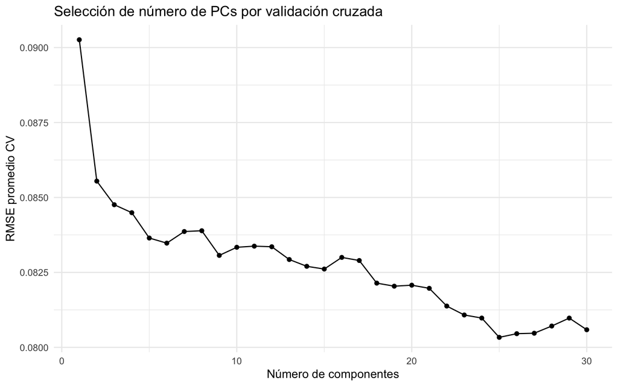

```r
pcr_cv_results %>%
  ggplot(aes(x = n_components, y = rmse_cv)) +
  geom_line() +
  geom_point() +
  labs(
    title = "Selección de número de PCs por validación cruzada",
    x = "Número de componentes",
    y = "RMSE promedio CV"
  )
```

```r
best_k <- pcr_cv_results %>%
  arrange(rmse_cv) %>%
  slice(1) %>%
  pull(n_components)

train_pcs_best <- as.data.frame(pca_train$x[, 1:best_k, drop = FALSE])
train_pcs_best$log_sale_price <- y_train

test_pcs_best <- predict(pca_train, newdata = x_test)[, 1:best_k, drop = FALSE] %>%
  as.data.frame()

lm_pcr_best <- lm(log_sale_price ~ ., data = train_pcs_best)

pred_pcr_best <- predict(lm_pcr_best, newdata = test_pcs_best)

metrics_pcr_best <- regression_metrics(
  y_test,
  pred_pcr_best,
  paste0("PCR CV, ", best_k, " PCs")
)

bind_rows(
  metrics_lm_original,
  metrics_pcr_90,
  metrics_pcr_best,
  metrics_ridge
)
```

[output not shown]

**Discusión.**  
PCA no siempre mejora la predicción. Su valor depende del objetivo. Para explicación y visualización suele ser muy útil. Para regresión lineal con colinealidad puede ayudar. Para predicción pura, Ridge o Lasso pueden competir o superar PCA.

# 13 11. Visualización de predicciones

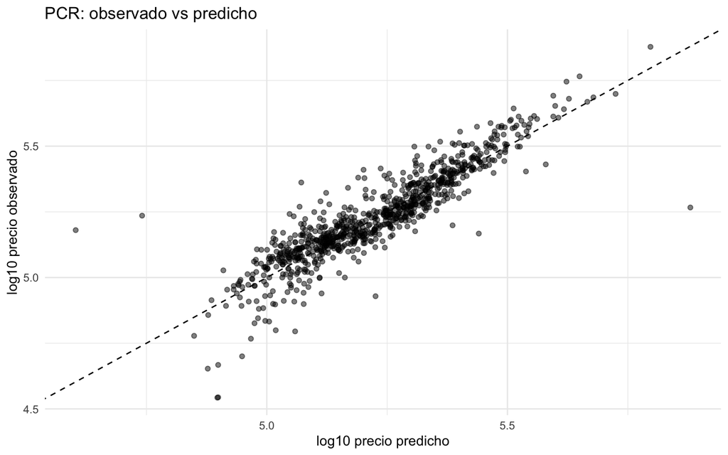

```r
tibble(
  observado = y_test,
  predicho = pred_pcr_best
) %>%
  ggplot(aes(x = predicho, y = observado)) +
  geom_point(alpha = 0.5) +
  geom_abline(slope = 1, intercept = 0, linetype = "dashed") +
  labs(
    title = "PCR: observado vs predicho",
    x = "log10 precio predicho",
    y = "log10 precio observado"
  )
```

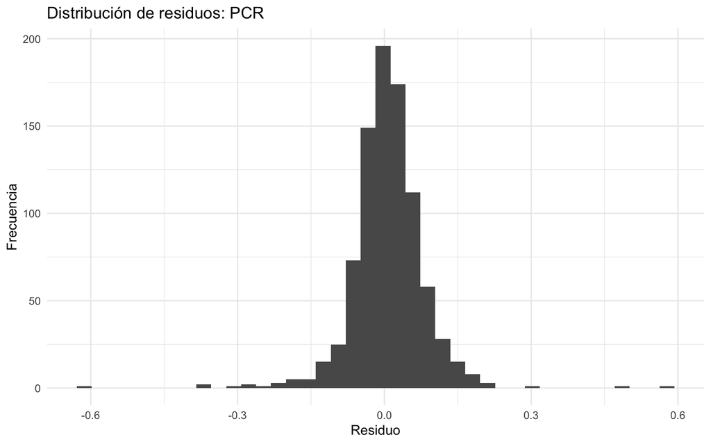

```r
tibble(
  residual = y_test - pred_pcr_best
) %>%
  ggplot(aes(x = residual)) +
  geom_histogram(bins = 40) +
  labs(
    title = "Distribución de residuos: PCR",
    x = "Residuo",
    y = "Frecuencia"
  )
```

# 14 12. PCA con variables mixtas: numéricas + categóricas

PCA clásico requiere variables numéricas. Con variables categóricas hay varias estrategias:

1. Usar solo variables numéricas.
2. Convertir categóricas a variables dummy y luego aplicar PCA (no recomendado).
3. Usar métodos más apropiados para variables mixtas, como FAMD.
4. Usar MCA si todas las variables son categóricas.

# 15 13. FAMD: alternativa para variables mixtas

FAMD significa **Factor Analysis of Mixed Data**. Es una extensión de PCA diseñada para datasets con variables numéricas y categóricas.

```r
ames_famd_data <- ames_raw %>%
  dplyr::select(
    Sale_Price,
    Gr_Liv_Area, Total_Bsmt_SF, Garage_Area, Year_Built,
    Overall_Qual, Neighborhood, Bldg_Type, House_Style, Central_Air
  ) %>%
  mutate(
    log_Sale_Price = log10(Sale_Price)
  ) %>%
  dplyr::select(-Sale_Price) %>%
  drop_na()

set.seed(123)
ames_famd_sample <- ames_famd_data %>%
  slice_sample(n = 800)

famd_res <- FAMD(
  ames_famd_sample %>% dplyr::select(-log_Sale_Price),
  ncp = 5,
  graph = FALSE
)
```

```r
summary(famd_res)
```

```
##
## Call:
## FAMD(base = ames_famd_sample %>% dplyr::select(-log_Sale_Price),
##      ncp = 5, graph = FALSE)
##
##
## Eigenvalues
##                       Dim.1  Dim.2  Dim.3  Dim.4  Dim.5
## Variance              4.002  2.164  1.989  1.714  1.613
## % of var.             7.847  4.243  3.901  3.361  3.163
## Cumulative % of var.  7.847 12.090 15.991 19.352 22.515
##
## Individuals (the 10 first)
##                    Dist    Dim.1    ctr   cos2    Dim.2    ctr   cos2    Dim.3
## 1              |  5.346 |  2.661  0.221  0.248 |  0.102  0.001  0.000 | -0.581
## 2              |  5.773 |  1.286  0.052  0.050 | -0.967  0.054  0.028 |  1.478
## 3              |  6.896 |  0.607  0.012  0.008 |  0.307  0.005  0.002 | -0.781
## 4              |  5.889 |  3.166  0.313  0.289 |  1.220  0.086  0.043 |  0.783
## 5              |  6.639 | -2.657  0.220  0.160 |  0.433  0.011  0.004 |  0.068
## 6              |  5.938 |  1.626  0.083  0.075 | -1.105  0.071  0.035 |  1.571
## 7              |  5.284 |  1.023  0.033  0.038 | -0.776  0.035  0.022 | -0.229
## 8              |  4.146 | -1.913  0.114  0.213 | -0.046  0.000  0.000 | -1.084
## 9              |  3.310 | -0.937  0.027  0.080 | -1.079  0.067  0.106 | -1.541
## 10             |  4.622 | -0.943  0.028  0.042 | -1.041  0.063  0.051 | -0.823
##                   ctr   cos2
## 1               0.021  0.012 |
## 2               0.137  0.066 |
## 3               0.038  0.013 |
## 4               0.039  0.018 |
## 5               0.000  0.000 |
## 6               0.155  0.070 |
## 7               0.003  0.002 |
## 8               0.074  0.068 |
## 9               0.149  0.217 |
## 10              0.043  0.032 |
##
## Continuous variables
##                   Dim.1    ctr   cos2    Dim.2    ctr   cos2    Dim.3    ctr
## Gr_Liv_Area    |  0.541  7.307  0.292 |  0.636 18.700  0.405 |  0.143  1.034
## Total_Bsmt_SF  |  0.664 11.011  0.441 |  0.074  0.255  0.006 | -0.403  8.165
```

[output cut: 16 more lines]

```
## Very_Good      |   2.645   4.914   0.503  13.306 |   0.905   1.966   0.059
## Excellent      |   3.702   2.354   0.274   8.797 |   1.368   1.100   0.037
## Very_Excellent |   4.076   1.297   0.161   6.480 |   3.546   3.357   0.122
## North_Ames     |  -0.625   0.415   0.064  -3.998 |  -0.744   2.009   0.090
##                 v.test     Dim.3     ctr    cos2  v.test
## Poor             0.850 |   0.276   0.012   0.000   0.438 |
## Fair             3.821 |   0.159   0.009   0.000   0.377 |
## Below_Average    1.191 |   0.440   0.348   0.011   2.441 |
## Average         -2.789 |  -0.864   5.755   0.193 -11.473 |
## Above_Average   -5.022 |   0.535   1.751   0.078   6.062 |
## Good            -2.244 |   0.699   2.578   0.090   7.197 |
## Very_Good        6.188 |  -0.018   0.001   0.000  -0.130 |
## Excellent        4.421 |  -1.085   0.817   0.024  -3.655 |
## Very_Excellent   7.667 |  -1.232   0.479   0.015  -2.777 |
## North_Ames      -6.470 |  -1.035   4.600   0.174  -9.386 |
```

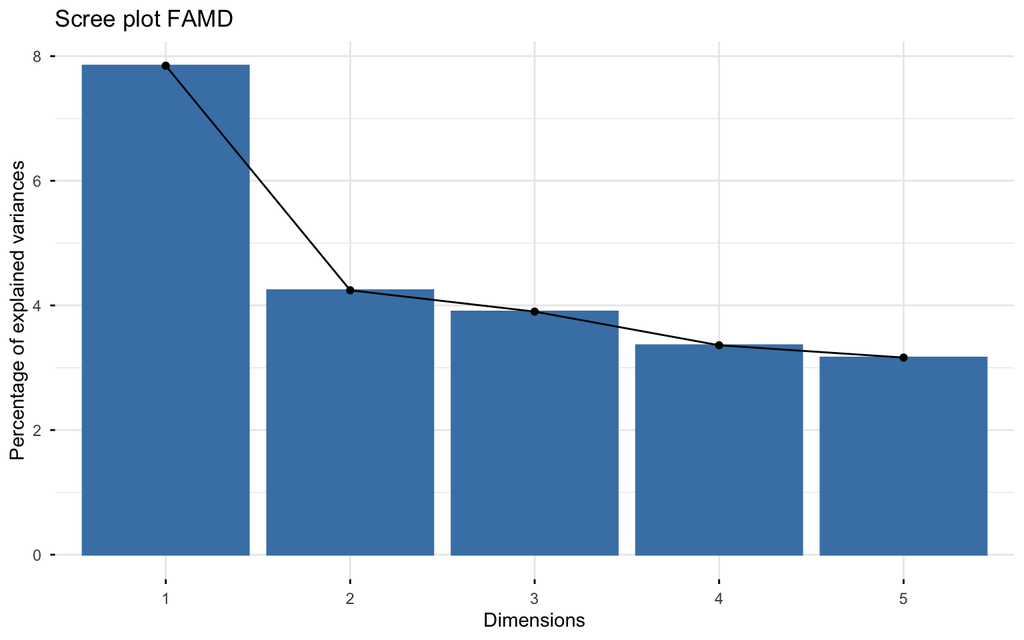

```r
fviz_screeplot(famd_res) +
  labs(title = "Scree plot FAMD")
```

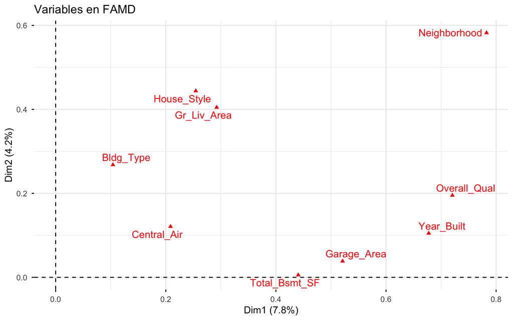

```r
fviz_famd_var(famd_res, repel = TRUE) +
  labs(title = "Variables en FAMD")
```

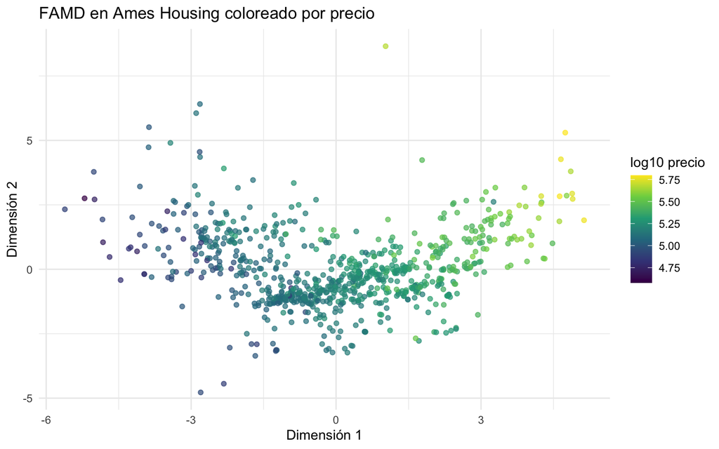

```r
famd_scores <- as_tibble(famd_res$ind$coord) %>%
  bind_cols(ames_famd_sample %>% dplyr::select(log_Sale_Price, Neighborhood))

famd_scores %>%
  ggplot(aes(x = Dim.1, y = Dim.2, color = log_Sale_Price)) +
  geom_point(alpha = 0.7) +
  scale_color_viridis_c() +
  labs(
    title = "FAMD en Ames Housing coloreado por precio",
    x = "Dimensión 1",
    y = "Dimensión 2",
    color = "log10 precio"
  )
```

# 16 14. PCA y regresión logística: Breast Cancer

Ahora usaremos PCA en clasificación binaria. El objetivo es predecir si un tumor es maligno o benigno usando variables morfológicas.

```r
data("BreastCancer", package = "mlbench")

bc <- BreastCancer %>%
  as_tibble() %>%
  dplyr::select(-Id) %>%
  mutate(
    Class = factor(Class),
    across(-Class, ~ as.numeric(as.character(.x)))
  ) %>%
  drop_na()

glimpse(bc)
```

```
## Rows: 683
## Columns: 10
## $ Cl.thickness    <dbl> 5, 5, 3, 6, 4, 8, 1, 2, 2, 4, 1, 2, 5, 1, 8, 7, 4, 4, …
## $ Cell.size       <dbl> 1, 4, 1, 8, 1, 10, 1, 1, 1, 2, 1, 1, 3, 1, 7, 4, 1, 1,…
## $ Cell.shape      <dbl> 1, 4, 1, 8, 1, 10, 1, 2, 1, 1, 1, 1, 3, 1, 5, 6, 1, 1,…
## $ Marg.adhesion   <dbl> 1, 5, 1, 1, 3, 8, 1, 1, 1, 1, 1, 1, 3, 1, 10, 4, 1, 1,…
## $ Epith.c.size    <dbl> 2, 7, 2, 3, 2, 7, 2, 2, 2, 2, 1, 2, 2, 2, 7, 6, 2, 2, …
## $ Bare.nuclei     <dbl> 1, 10, 2, 4, 1, 10, 10, 1, 1, 1, 1, 1, 3, 3, 9, 1, 1, …
## $ Bl.cromatin     <dbl> 3, 3, 3, 3, 3, 9, 3, 3, 1, 2, 3, 2, 4, 3, 5, 4, 2, 3, …
## $ Normal.nucleoli <dbl> 1, 2, 1, 7, 1, 7, 1, 1, 1, 1, 1, 1, 4, 1, 5, 3, 1, 1, …
## $ Mitoses         <dbl> 1, 1, 1, 1, 1, 1, 1, 1, 5, 1, 1, 1, 1, 1, 4, 1, 1, 1, …
## $ Class           <fct> benign, benign, benign, benign, benign, malignant, ben…
```

```r
table(bc$Class)
```

```
##
##    benign malignant
##       444       239
```

```r
set.seed(123)

idx_bc <- sample(seq_len(nrow(bc)), size = floor(0.70 * nrow(bc)))

bc_train <- bc[idx_bc, ]
bc_test <- bc[-idx_bc, ]

x_train_bc <- bc_train %>% dplyr::select(-Class)
x_test_bc <- bc_test %>% dplyr::select(-Class)

y_train_bc <- bc_train$Class
y_test_bc <- bc_test$Class
```

## 16.1 14.1 Regresión logística con variables originales

```r
x_train_bc_scaled <- scale(x_train_bc)

train_bc_original <- as.data.frame(x_train_bc_scaled)
train_bc_original$Class <- y_train_bc

x_test_bc_scaled <- scale(
  x_test_bc,
  center = attr(x_train_bc_scaled, "scaled:center"),
  scale = attr(x_train_bc_scaled, "scaled:scale")
)

test_bc_original <- as.data.frame(x_test_bc_scaled)

logit_original <- glm(
  Class ~ .,
  data = train_bc_original,
  family = binomial
)

prob_original <- predict(
  logit_original,
  newdata = test_bc_original,
  type = "response"
)

pred_original <- ifelse(prob_original > 0.5, "malignant", "benign") %>%
  factor(levels = levels(y_test_bc))

mean(pred_original == y_test_bc)
```

```
## [1] 0.9707317
```

```r
table(real = y_test_bc, predicho = pred_original)
```

```
##            predicho
## real        benign malignant
##   benign       136         3
##   malignant      3        63
```

## 16.2 14.2 PCA + regresión logística

```r
pca_bc <- prcomp(
  x_train_bc,
  center = TRUE,
  scale. = TRUE
)

var_bc <- pca_bc$sdev^2 / sum(pca_bc$sdev^2)
cum_bc <- cumsum(var_bc)
k_bc_90 <- which(cum_bc >= 0.90)[1]

k_bc_90
```

```
## [1] 6
```

```r
train_bc_pcs <- as.data.frame(pca_bc$x[, 1:k_bc_90, drop = FALSE])
train_bc_pcs$Class <- y_train_bc

test_bc_pcs <- predict(pca_bc, newdata = x_test_bc)[, 1:k_bc_90, drop = FALSE] %>%
  as.data.frame()

logit_pca <- glm(
  Class ~ .,
  data = train_bc_pcs,
  family = binomial
)

prob_pca <- predict(
  logit_pca,
  newdata = test_bc_pcs,
  type = "response"
)

pred_pca <- ifelse(prob_pca > 0.5, "malignant", "benign") %>%
  factor(levels = levels(y_test_bc))

mean(pred_pca == y_test_bc)
```

```
## [1] 0.9707317
```

```r
table(real = y_test_bc, predicho = pred_pca)
```

```
##            predicho
## real        benign malignant
##   benign       136         3
##   malignant      3        63
```

```r
roc_obj <- roc(
  response = y_test_bc,
  predictor = as.numeric(prob_pca),
  levels = levels(y_test_bc)
)

auc(roc_obj)
```

```
## Area under the curve: 0.9963
```

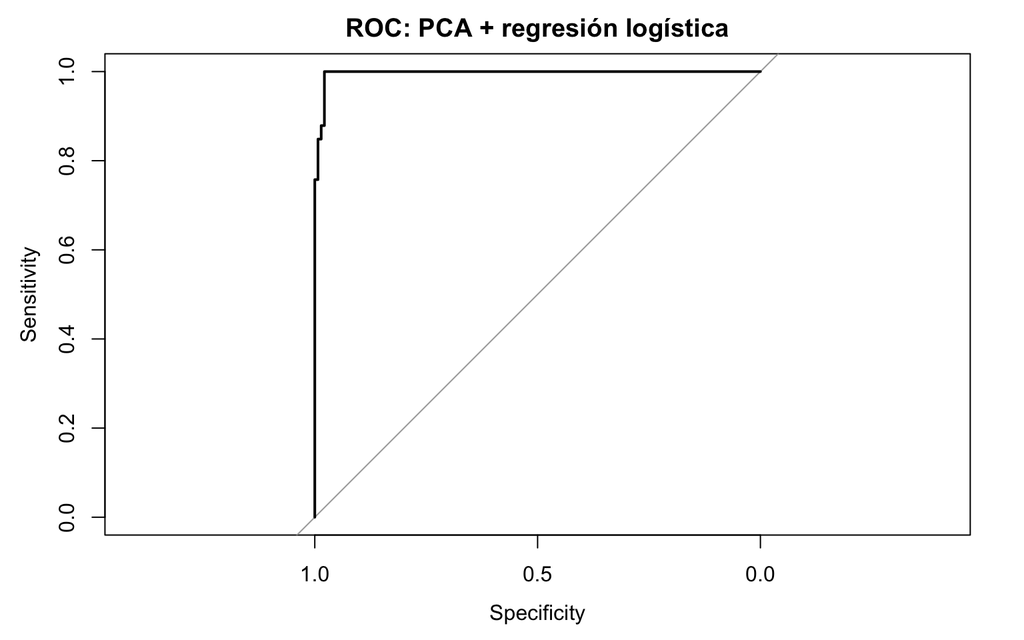

```r
plot(roc_obj, main = "ROC: PCA + regresión logística")
```

## 16.3 14.3 Visualización PCA para Breast Cancer

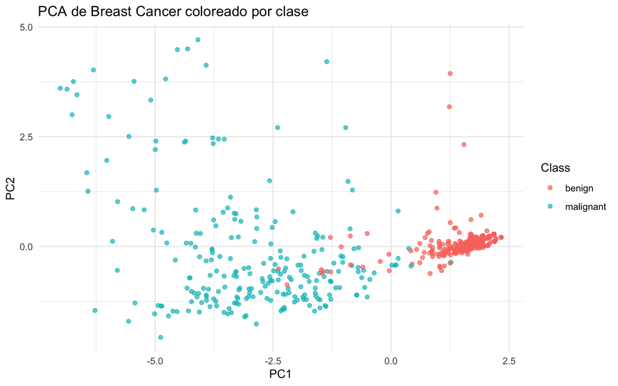

```r
pca_bc_full <- prcomp(
  bc %>% dplyr::select(-Class),
  center = TRUE,
  scale. = TRUE
)

bc_scores <- as_tibble(pca_bc_full$x) %>%
  bind_cols(bc %>% dplyr::select(Class))

bc_scores %>%
  ggplot(aes(x = PC1, y = PC2, color = Class)) +
  geom_point(alpha = 0.7) +
  labs(
    title = "PCA de Breast Cancer coloreado por clase",
    x = "PC1",
    y = "PC2"
  )
```

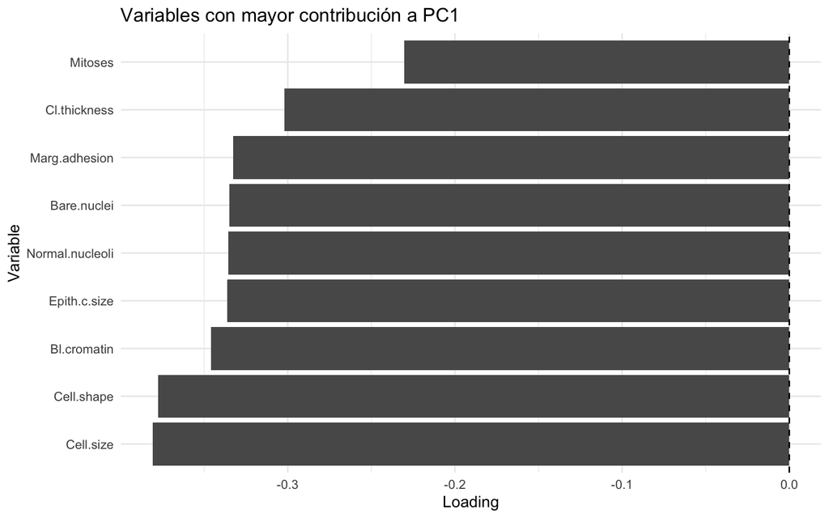

```r
bc_loadings <- as.data.frame(pca_bc_full$rotation) %>%
  rownames_to_column("variable")

plot_loadings(bc_loadings, "PC1", 10)
```

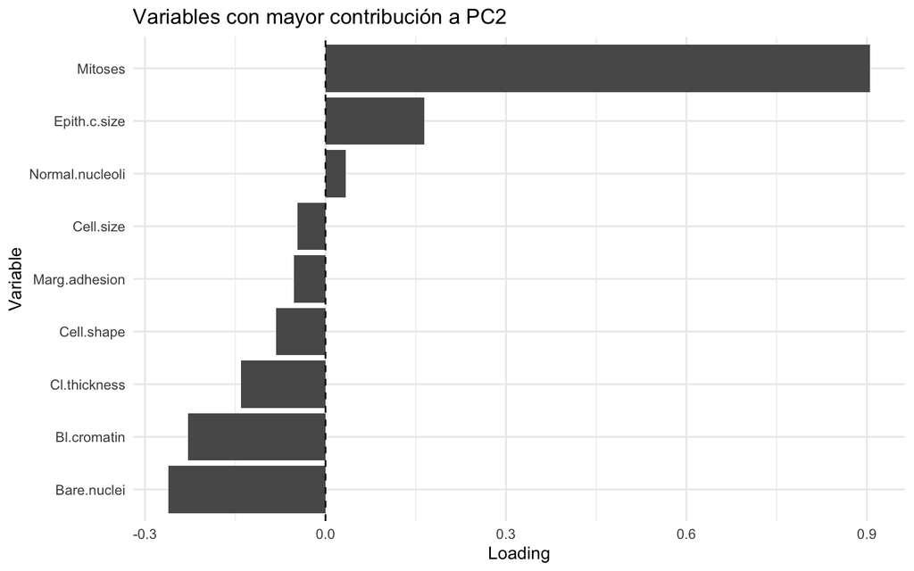

```r
plot_loadings(bc_loadings, "PC2", 10)
```

**Interpretación.**  
Si las clases se separan en PC1 y PC2, significa que los principales ejes de variación morfológica están asociados a la condición tumoral.

# 17 15. PCA con iris: clasificación simple y didáctica

```r
iris_tbl <- as_tibble(iris)

pca_iris <- prcomp(
  iris_tbl %>% dplyr::select(-Species),
  center = TRUE,
  scale. = TRUE
)

summary(pca_iris)
```

```
## Importance of components:
##                           PC1    PC2     PC3     PC4
## Standard deviation     1.7084 0.9560 0.38309 0.14393
## Proportion of Variance 0.7296 0.2285 0.03669 0.00518
## Cumulative Proportion  0.7296 0.9581 0.99482 1.00000
```

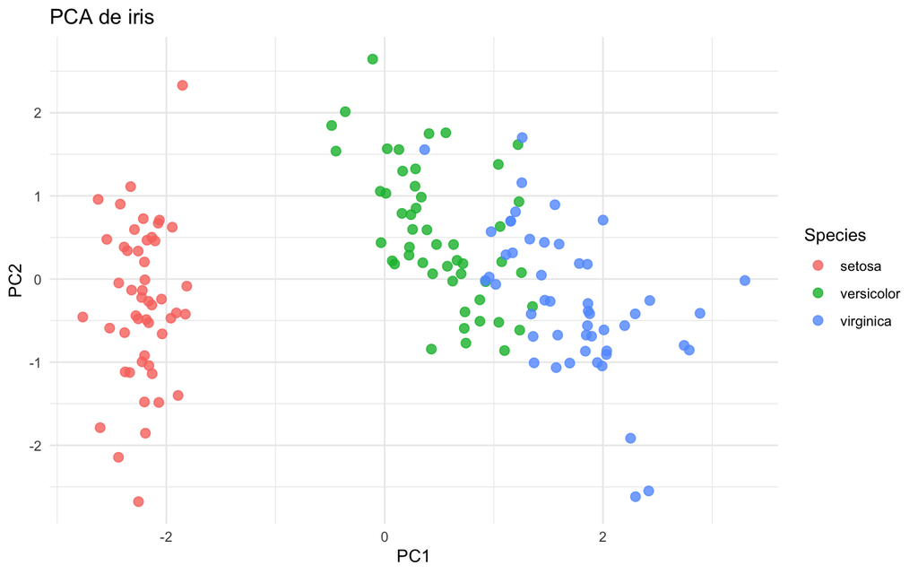

```r
iris_scores <- as_tibble(pca_iris$x) %>%
  bind_cols(iris_tbl %>% dplyr::select(Species))

iris_scores %>%
  ggplot(aes(x = PC1, y = PC2, color = Species)) +
  geom_point(size = 2.5, alpha = 0.8) +
  labs(
    title = "PCA de iris",
    x = "PC1",
    y = "PC2"
  )
```

```r
iris_loadings <- as.data.frame(pca_iris$rotation) %>%
  rownames_to_column("variable")

iris_loadings
```

```
##       variable        PC1         PC2        PC3        PC4
## 1 Sepal.Length  0.5210659 -0.37741762  0.7195664  0.2612863
## 2  Sepal.Width -0.2693474 -0.92329566 -0.2443818 -0.1235096
## 3 Petal.Length  0.5804131 -0.02449161 -0.1421264 -0.8014492
## 4  Petal.Width  0.5648565 -0.06694199 -0.6342727  0.5235971
```

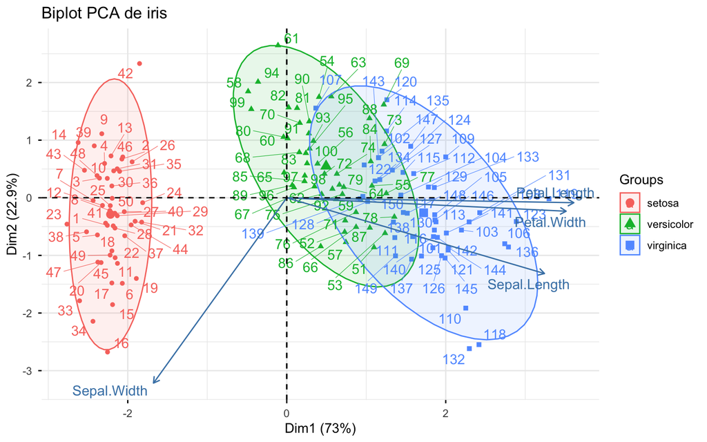

```r
fviz_pca_biplot(
  pca_iris,
  habillage = iris$Species,
  repel = TRUE,
  addEllipses = TRUE
) +
  labs(title = "Biplot PCA de iris")
```

## 17.1 Preguntas

1. ¿Qué especie se separa mejor?
2. ¿Qué variables dominan PC1?
3. ¿Qué variables dominan PC2?
4. ¿Por qué `Petal.Length` y `Petal.Width` son tan importantes?
5. ¿Hay solapamiento entre `versicolor` y `virginica`?

# 18 16. PCA para `flights`: retrasos, distancia y velocidad

Usaremos `nycflights13::flights` para mostrar PCA en variables operacionales.

Creamos variables:

- `gain = dep_delay - arr_delay`
- `speed = distance / air_time * 60`
- `delayed`: vuelo atrasado si `arr_delay > 15`.

```r
flights_pca <- flights %>%
  dplyr::select(month, dep_delay, arr_delay, distance, air_time, carrier, origin) %>%
  drop_na() %>%
  mutate(
    gain = dep_delay - arr_delay,
    speed = distance / air_time * 60,
    delayed = if_else(arr_delay > 15, "delayed", "not_delayed"),
    delayed = factor(delayed)
  ) %>%
  filter(speed > 100, speed < 800)

glimpse(flights_pca)
```

```
## Rows: 327,338
## Columns: 10
## $ month     <int> 1, 1, 1, 1, 1, 1, 1, 1, 1, 1, 1, 1, 1, 1, 1, 1, 1, 1, 1, 1, …
## $ dep_delay <dbl> 2, 4, 2, -1, -6, -4, -5, -3, -3, -2, -2, -2, -2, -2, -1, 0, …
## $ arr_delay <dbl> 11, 20, 33, -18, -25, 12, 19, -14, -8, 8, -2, -3, 7, -14, 31…
## $ distance  <dbl> 1400, 1416, 1089, 1576, 762, 719, 1065, 229, 944, 733, 1028,…
## $ air_time  <dbl> 227, 227, 160, 183, 116, 150, 158, 53, 140, 138, 149, 158, 3…
## $ carrier   <chr> "UA", "UA", "AA", "B6", "DL", "UA", "B6", "EV", "B6", "AA", …
## $ origin    <chr> "EWR", "LGA", "JFK", "JFK", "LGA", "EWR", "EWR", "LGA", "JFK…
## $ gain      <dbl> -9, -16, -31, 17, 19, -16, -24, 11, 5, -10, 0, 1, -9, 12, -3…
## $ speed     <dbl> 370.0441, 374.2731, 408.3750, 516.7213, 394.1379, 287.6000, …
## $ delayed   <fct> not_delayed, delayed, delayed, not_delayed, not_delayed, not…
```

```r
flights_num <- flights_pca %>%
  dplyr::select(month, dep_delay, arr_delay, distance, air_time, gain, speed)

pca_flights <- prcomp(
  flights_num,
  center = TRUE,
  scale. = TRUE
)

summary(pca_flights)
```

```
## Importance of components:
##                           PC1    PC2    PC3    PC4     PC5     PC6       PC7
## Standard deviation     1.6217 1.4075 1.0066 1.0003 0.60873 0.06662 4.724e-13
## Proportion of Variance 0.3757 0.2830 0.1448 0.1429 0.05294 0.00063 0.000e+00
## Cumulative Proportion  0.3757 0.6587 0.8035 0.9464 0.99937 1.00000 1.000e+00
```

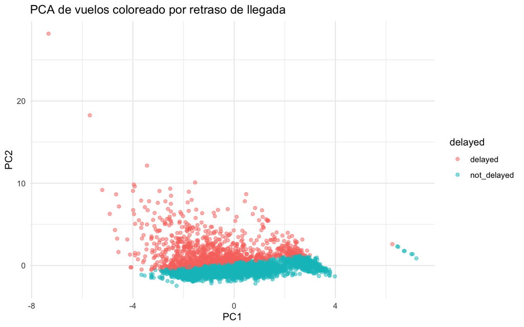

```r
flights_scores <- as_tibble(pca_flights$x) %>%
  bind_cols(flights_pca %>% dplyr::select(carrier, origin, delayed, arr_delay, dep_delay))

flights_scores %>%
  slice_sample(n = 5000) %>%
  ggplot(aes(x = PC1, y = PC2, color = delayed)) +
  geom_point(alpha = 0.5) +
  labs(
    title = "PCA de vuelos coloreado por retraso de llegada",
    x = "PC1",
    y = "PC2"
  )
```

```r
flights_loadings <- as.data.frame(pca_flights$rotation) %>%
  rownames_to_column("variable")

flights_loadings
```

```
##    variable         PC1         PC2         PC3         PC4         PC5
## 1     month  0.03419267 -0.01117558 -0.17747749 -0.98100122  0.06953515
## 2 dep_delay -0.14326638  0.62206514  0.40906141 -0.07909652  0.09833768
## 3 arr_delay -0.21344273  0.66565096  0.03310513 -0.02406724 -0.04287797
## 4  distance  0.57191065  0.20481121 -0.15306877  0.06207587  0.26853405
## 5  air_time  0.55083031  0.21923741 -0.22082453  0.08432290  0.36075447
## 6      gain  0.20987012 -0.26527511  0.82653799 -0.11611647  0.32446192
## 7     speed  0.50814025  0.09713558  0.21146151 -0.07971396 -0.82226892
##            PC6           PC7
## 1 -0.003029228  9.575620e-15
## 2 -0.005970222  6.397001e-01
## 3  0.005229708 -7.126079e-01
## 4  0.729092983  1.682398e-14
## 5 -0.680075965 -1.675435e-14
## 6 -0.026196279 -2.880517e-01
## 7 -0.071844897 -1.356856e-15
```

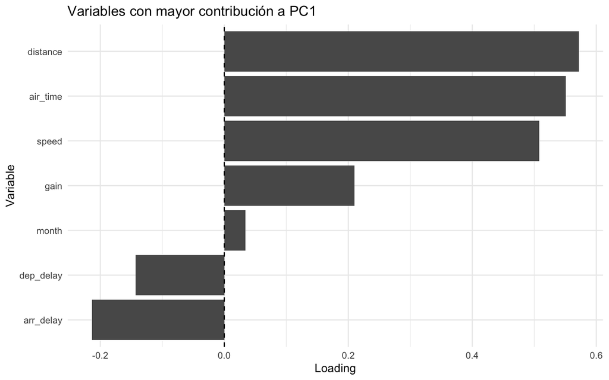

```r
plot_loadings(flights_loadings, "PC1", 7)
```

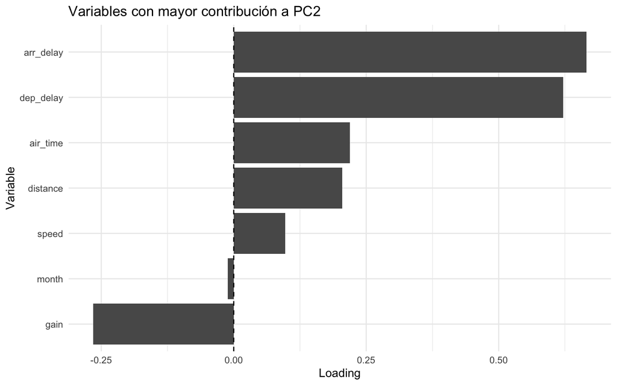

```r
plot_loadings(flights_loadings, "PC2", 7)
```

```r
flights_scores %>%
  dplyr::select(PC1:PC5, arr_delay, dep_delay) %>%
  cor(use = "pairwise.complete.obs") %>%
  round(2)
```

```
##             PC1  PC2  PC3   PC4   PC5 arr_delay dep_delay
## PC1        1.00 0.00 0.00  0.00  0.00     -0.35     -0.23
## PC2        0.00 1.00 0.00  0.00  0.00      0.94      0.88
## PC3        0.00 0.00 1.00  0.00  0.00      0.03      0.41
## PC4        0.00 0.00 0.00  1.00  0.00     -0.02     -0.08
## PC5        0.00 0.00 0.00  0.00  1.00     -0.03      0.06
## arr_delay -0.35 0.94 0.03 -0.02 -0.03      1.00      0.91
## dep_delay -0.23 0.88 0.41 -0.08  0.06      0.91      1.00
```

**Interpretación posible.**  
En `flights`, un componente puede capturar retrasos (`dep_delay`, `arr_delay`), otro puede capturar escala del vuelo (`distance`, `air_time`) y otro eficiencia o recuperación de tiempo (`gain`, `speed`).

# 19 17. PCA y colinealidad: ejemplo simulado

PCA es muy útil cuando hay variables altamente correlacionadas.

```r
set.seed(123)

n <- 500
x1 <- rnorm(n)
x2 <- x1 + rnorm(n, sd = 0.1)
x3 <- x1 - x2 + rnorm(n, sd = 0.1)
y <- 3*x1 + 3*x2 + rnorm(n, sd = 1)

sim_data <- tibble(x1, x2, x3, y)

cor(sim_data)
```

```
##            x1          x2          x3           y
## x1 1.00000000 0.994600316 0.080229361 0.982216384
## x2 0.99460032 1.000000000 0.007930897 0.984274180
## x3 0.08022936 0.007930897 1.000000000 0.009492076
## y  0.98221638 0.984274180 0.009492076 1.000000000
```

```r
simple_model=lm(y ~ x2, data=sim_data)
```

```r
sim_pca <- prcomp(
  sim_data %>% dplyr::select(x1, x2, x3),
  center = TRUE,
  scale. = TRUE
)

summary(sim_pca)
```

```
## Importance of components:
##                           PC1    PC2     PC3
## Standard deviation     1.4137 0.9994 0.05267
## Proportion of Variance 0.6662 0.3329 0.00092
## Cumulative Proportion  0.6662 0.9991 1.00000
```

```r
as.data.frame(sim_pca$rotation) %>%
  rownames_to_column("variable")
```

```
##   variable        PC1          PC2         PC3
## 1       x1 0.70685983  0.007845156  0.70731014
## 2       x2 0.70459657  0.080391327 -0.70503965
## 3       x3 0.06239275 -0.996732506 -0.05129773
```

```r
sim_scores <- as_tibble(sim_pca$x) %>%
  mutate(y = sim_data$y)

lm_original_sim <- lm(y ~ x1 + x2 + x3, data = sim_data)
lm_pca_sim <- lm(y ~ PC1 + PC2, data = sim_scores)

summary(lm_original_sim)
```

```
##
## Call:
## lm(formula = y ~ x1 + x2 + x3, data = sim_data)
##
## Residuals:
##      Min       1Q   Median       3Q      Max
## -2.90082 -0.66163  0.01468  0.73209  2.89953
##
## Coefficients:
##             Estimate Std. Error t value Pr(>|t|)
## (Intercept)  0.06513    0.04513   1.443 0.149634
## x1           3.41092    0.62357   5.470 7.15e-08 ***
## x2           2.53854    0.62157   4.084 5.16e-05 ***
## x3          -1.66741    0.45606  -3.656 0.000283 ***
## ---
## Signif. codes:  0 '***' 0.001 '**' 0.01 '*' 0.05 '.' 0.1 ' ' 1
##
## Residual standard error: 1.008 on 496 degrees of freedom
## Multiple R-squared:  0.9706, Adjusted R-squared:  0.9704
## F-statistic:  5453 on 3 and 496 DF,  p-value: < 2.2e-16
```

```r
summary(lm_pca_sim)
```

```
##
## Call:
## lm(formula = y ~ PC1 + PC2, data = sim_scores)
##
## Residuals:
##      Min       1Q   Median       3Q      Max
## -2.90513 -0.65288  0.01367  0.72485  2.92469
##
## Coefficients:
##             Estimate Std. Error t value Pr(>|t|)
## (Intercept)  0.26557    0.04507   5.893 7.01e-09 ***
## PC1          4.07097    0.03191 127.569  < 2e-16 ***
## PC2          0.45396    0.04514  10.056  < 2e-16 ***
## ---
## Signif. codes:  0 '***' 0.001 '**' 0.01 '*' 0.05 '.' 0.1 ' ' 1
##
## Residual standard error: 1.008 on 497 degrees of freedom
## Multiple R-squared:  0.9705, Adjusted R-squared:  0.9704
## F-statistic:  8187 on 2 and 497 DF,  p-value: < 2.2e-16
```

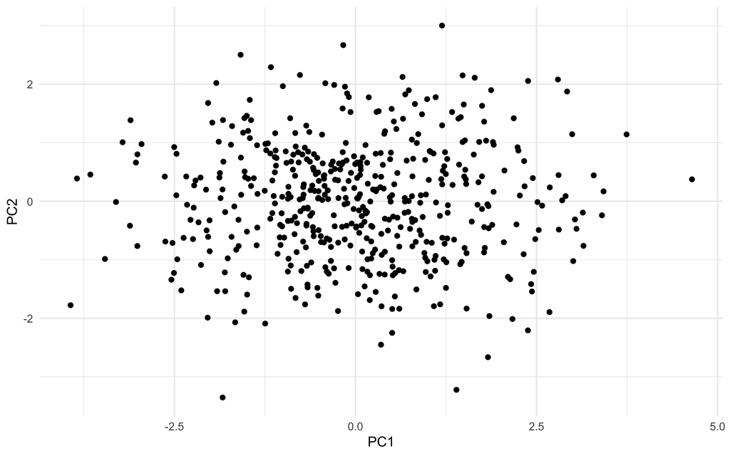

```r
lm_one_pc=lm(y~PC1, data=sim_scores)

lm_one_pc=lm(y~PC2, data=sim_scores)


sim_scores %>% ggplot(aes(x=PC1,y=PC2)) + geom_point()
```

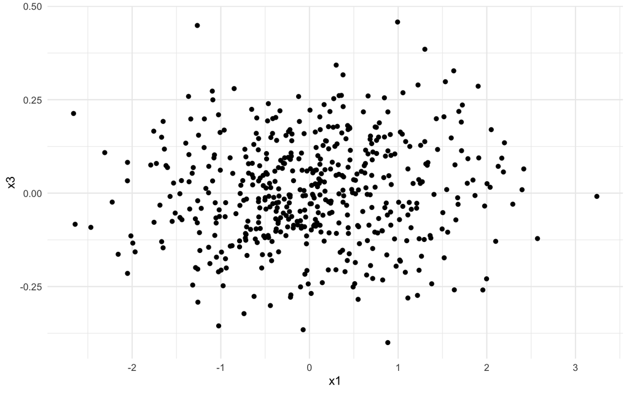

```r
sim_data %>% ggplot(aes(x=x1,y=x3)) + geom_point()
```

**Discusión.**  
El modelo original puede tener coeficientes inestables por colinealidad. El modelo con PCs usa predictores ortogonales, lo que mejora estabilidad matemática, aunque reduce interpretabilidad directa.

# 20 18. PCA versus regularización

PCA y Ridge/Lasso resuelven problemas relacionados, pero no equivalentes.

## 20.1 PCA

- Crea nuevas variables.
- No usa la respuesta.
- Reduce dimensión.
- Mejora colinealidad.
- Puede dificultar interpretación.

## 20.2 Ridge

- Mantiene variables originales.
- Usa la respuesta.
- Penaliza coeficientes grandes.
- Maneja colinealidad.
- Conserva interpretabilidad parcial.

## 20.3 Lasso

- Puede seleccionar variables.
- Útil cuando se quiere un modelo más parsimonioso.

# 21 19. Sparse PCA

Sparse PCA busca componentes con pocos loadings distintos de cero. Esto puede facilitar interpretación.

```r
corr_price <- ames_raw %>%
  dplyr::select(where(is.numeric)) %>%
  cor(use = "pairwise.complete.obs") %>%
  as.data.frame() %>%
  rownames_to_column("variable") %>%
  dplyr::select(variable, Sale_Price) %>%
  arrange(desc(abs(Sale_Price)))

top_vars <- corr_price %>%
  filter(variable != "Sale_Price") %>%
  slice(1:15) %>%
  pull(variable) %>%
  janitor::make_clean_names()

X_top <- ames_num_imp %>%
  dplyr::select(any_of(top_vars)) %>%
  scale()

spca_res <- elasticnet::spca(
  X_top,
  K = 3,
  type = "predictor",
  sparse = "varnum",
  para = c(5, 5, 5)
)
```

```
## You may wish to restart and use a more efficient way
## let the argument x be the sample covariance/correlation matrix and set type=Gram
```

```r
spca_loadings <- as.data.frame(spca_res$loadings) %>%
  rownames_to_column("variable")

spca_loadings %>% arrange(desc(abs(PC2)))
```

```
##           variable         PC1        PC2        PC3
## 1     first_flr_sf  0.00000000 -0.7822917 0.00000000
## 2    total_bsmt_sf  0.00000000 -0.5402598 0.00000000
## 3      garage_area  0.00000000 -0.1975225 0.19279561
## 4       fireplaces -0.02624596 -0.1741077 0.00000000
## 5     mas_vnr_area  0.00000000 -0.1637390 0.00000000
## 6      gr_liv_area -0.78511342  0.0000000 0.00000000
## 7      garage_cars  0.00000000  0.0000000 0.49586011
## 8       year_built  0.00000000  0.0000000 0.68593804
## 9        full_bath -0.14554424  0.0000000 0.04043715
## 10  year_remod_add  0.00000000  0.0000000 0.49477919
## 11 tot_rms_abv_grd -0.49864131  0.0000000 0.00000000
## 12    wood_deck_sf  0.00000000  0.0000000 0.00000000
## 13   open_porch_sf  0.00000000  0.0000000 0.00000000
## 14        latitude  0.00000000  0.0000000 0.00000000
## 15       half_bath -0.33627636  0.0000000 0.00000000
```

# 22 20. PCA, batches y metadata técnica

En datos reales, especialmente ómicos, PCA puede capturar efectos técnicos.

Ejemplos de metadata técnica:

- Batch de secuenciación.
- Fecha de procesamiento.
- Centro clínico.
- Operador.
- Plataforma.
- Profundidad de secuenciación.
- Porcentaje de lecturas mapeadas.
- RIN en RNA-seq.
- Porcentaje tumoral.
- Tiempo de isquemia.

**Recomendación.**  
Siempre correlaciona PCs con metadata técnica y biológica. Si PC1 se asocia más con batch que con biología, el análisis puede estar dominado por artefactos.

# 23 22. Ejemplo simulado de batch effect

Simulamos datos donde PC1 captura batch, no biología.

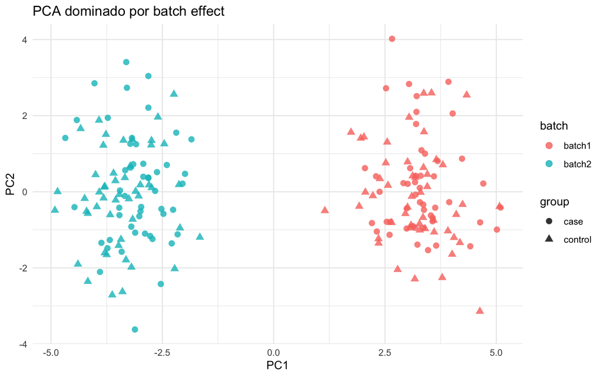

```r
set.seed(123)

n <- 200
p <- 50

group <- rep(c("control", "case"), each = n/2)
batch <- rep(c("batch1", "batch2"), times = n/2)

X <- matrix(rnorm(n*p), nrow = n, ncol = p)

# Efecto biológico débil en variables 1:5
X[group == "case", 1:5] <- X[group == "case", 1:5] + 0.5

# Batch effect fuerte en variables 20:40
X[batch == "batch2", 20:40] <- X[batch == "batch2", 20:40] + 2

sim_batch <- as_tibble(X)
colnames(sim_batch) <- paste0("var", 1:p)

pca_batch <- prcomp(sim_batch, center = TRUE, scale. = TRUE)

batch_scores <- as_tibble(pca_batch$x) %>%
  mutate(group = group, batch = batch)

batch_scores %>%
  ggplot(aes(x = PC1, y = PC2, color = batch, shape = group)) +
  geom_point(size = 2.5, alpha = 0.8) +
  labs(
    title = "PCA dominado por batch effect",
    x = "PC1",
    y = "PC2"
  )
```

```r
batch_scores %>%
  mutate(
    group_num = if_else(group == "case", 1, 0),
    batch_num = if_else(batch == "batch2", 1, 0)
  ) %>%
  dplyr::select(PC1:PC5, group_num, batch_num) %>%
  cor() %>%
  round(2)
```

```
##             PC1   PC2   PC3  PC4  PC5 group_num batch_num
## PC1        1.00  0.00  0.00 0.00 0.00      0.04     -0.98
## PC2        0.00  1.00  0.00 0.00 0.00      0.10     -0.01
## PC3        0.00  0.00  1.00 0.00 0.00     -0.10     -0.04
## PC4        0.00  0.00  0.00 1.00 0.00      0.06      0.01
## PC5        0.00  0.00  0.00 0.00 1.00      0.05      0.00
## group_num  0.04  0.10 -0.10 0.06 0.05      1.00      0.00
## batch_num -0.98 -0.01 -0.04 0.01 0.00      0.00      1.00
```

**Interpretación.**  
Aunque existe una señal biológica simulada, el batch effect es más fuerte y domina PC1. Esta situación es común en ómicas y datos biomédicos.